# Client Satisfaction Report

2019-2020 Survey Results

December 2019 (Survey 1)

**Introduction to Quarter 1 Results (Fall, 2019)**

The 2019-2020 OCIO customer sat survey builds on the lessons learned from the four surveys done during 2018-2019, and focuses on 6 questions grouped into 3 categories:

Empathy

- 1A TSG representatives are always able to understand my problems / needs.
- 1B TSG representatives ask the right questions and listen to my input.
- 1C TSG representatives stay in touch until my problems are resolved or my needs are met.

Expertise

- 2A TSG representatives always have the knowledge to address my needs.
- 2B TSG representatives address my needs completely and professionally.

Efficiency

- 3x TSG representatives always resolve my needs or problems within my required timeframes

These questions were sent out to a randomly selected sample of 25% of the entire TMC population. By randomly selecting responders each time, we should achieve more statistically significant results. By running the survey 4 times over the course of the year (that is, but not surveying the entire population once), it should make it possible to see if any corrections or improvements made along the way have improved the overall scores. Responses were only counted where a 1-10 value was given; that is, missing, “N/A” or “Do Not Use” responses were not figured into the averages.

The data is shown for OCIO overall and with group and question breakouts:

- Overall results show how OCIO did by group and by question
- Group breakouts show each group scored by question
- Question breakouts show each question scored by group

General Observations

- Scores were clustered; that is, they were closely grouped between a low of 7.65 and a high of 9.17 (a span of 1.52)
- The closeness of the scores / range makes it difficult to discern major differences between strengths and weaknesses
- However, the points below *may* be useful for the management team to consider
- Questions
  - Question 1A (Always understands my problem) at an average of 8.64 was the highest scoring question overall. B&MPS and the Service Desk and B&MPS scored higher and Project Support and Business Analysts scored lower - but the range was only 0.87.
  - Question 3 (Efficiency) at 8.19 was the lowest scoring question overall Scores were higher for B&MPS and the Service desk; the other groups were clustered within 0.20 points of each other.
- Groups
  - The highest and lowest were separated by a small margin (1.09 points)
  - B&MPS and the Service Desk were the highest performing groups, tying at a 8.98 overall average score
  - B&MPS scored high on expertise (questions 2A and 2B) and was strong overall (scores were highly clustered)
  - The Service Desk scored higher on Empathy (questions 1A-1C) but lower on Knowledge (2A)
  - Project Support scored lower overall (7.89) with a weakness in Knowledge but strength in Empathy
  - Account Managers, Business Analysts, and Vendor Managers formed a middle tier, clustered between 8.19 and 8.39 (0.20 points); they scored lowest on question 3 (efficiency)

What these Results (May) Imply

- There is general strength in all areas sampled - scores ranged between 8.19 and 8.64 overall (a range of only 0.45), which is relatively tight. Empathy appears to be a strength to build on
- Individual scores in expertise were mixed and may suggest a need to focus on the perceptions around those groups scoring lower (that is, all but B&MPS and the Service Desk)
- Similarly, except for B&MPS and the Service Desk, there may be an opportunity to improve on Efficiency (speed) across all the groups

**Summary Charts**

Total Responses for Q1: 41

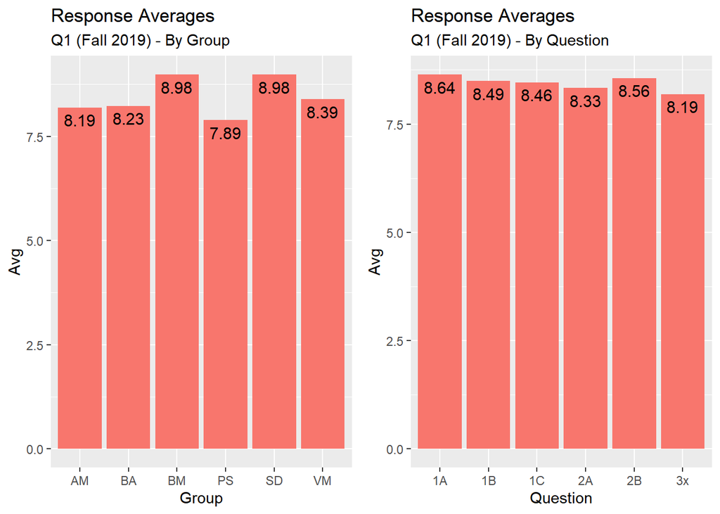

**Group Breakouts**

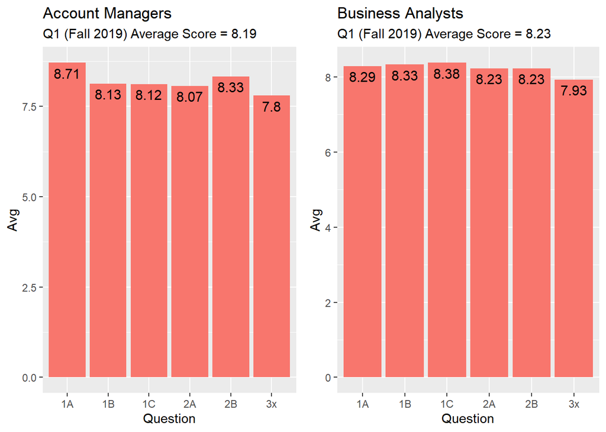

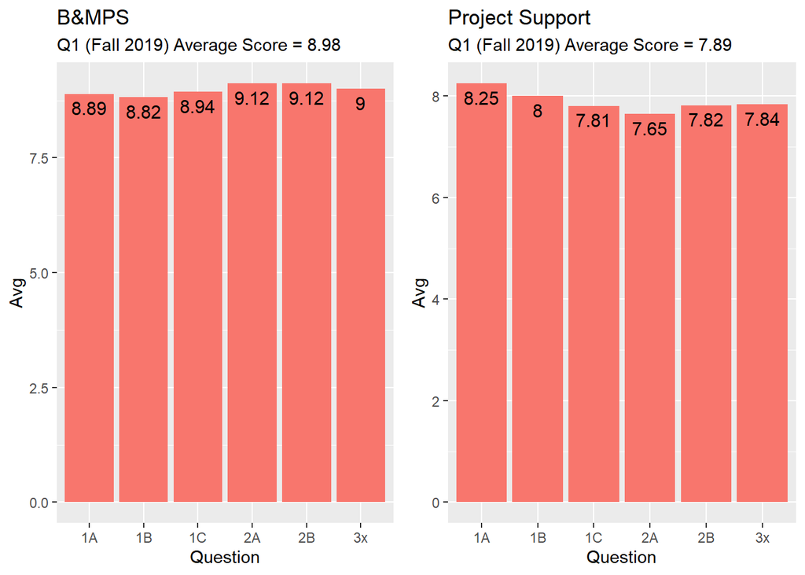

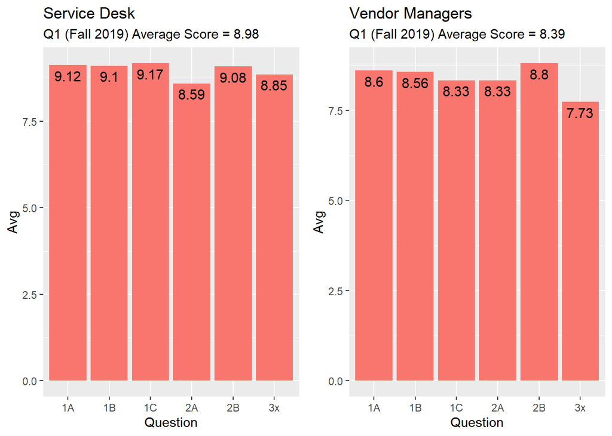

**Question Breakouts**

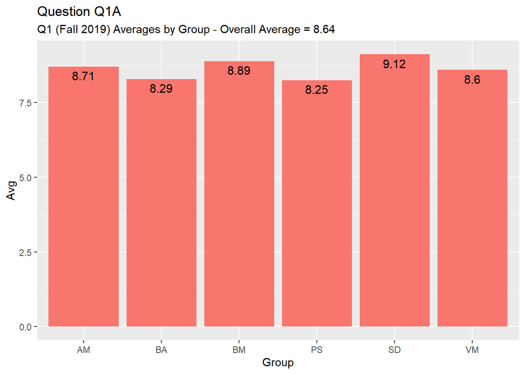

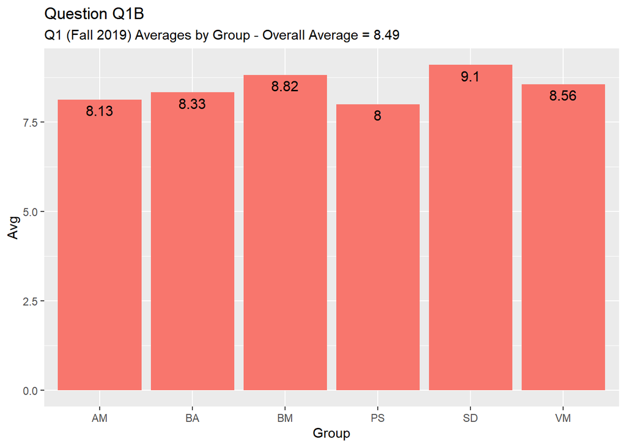

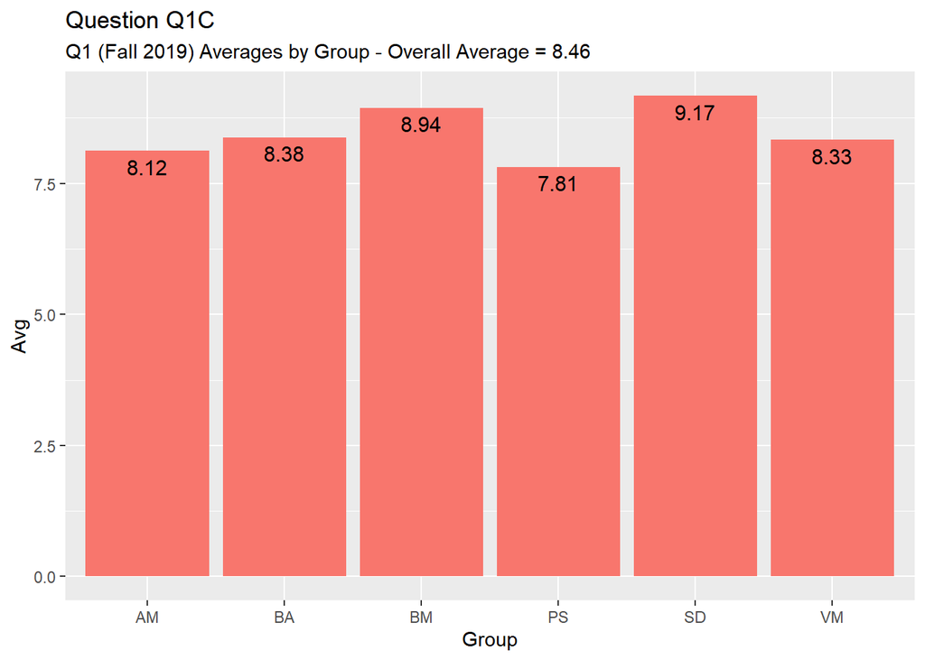

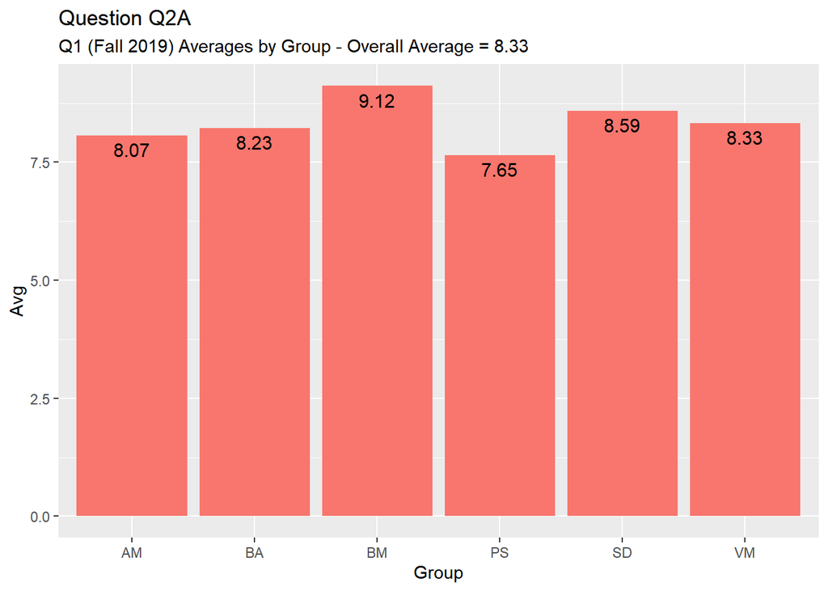

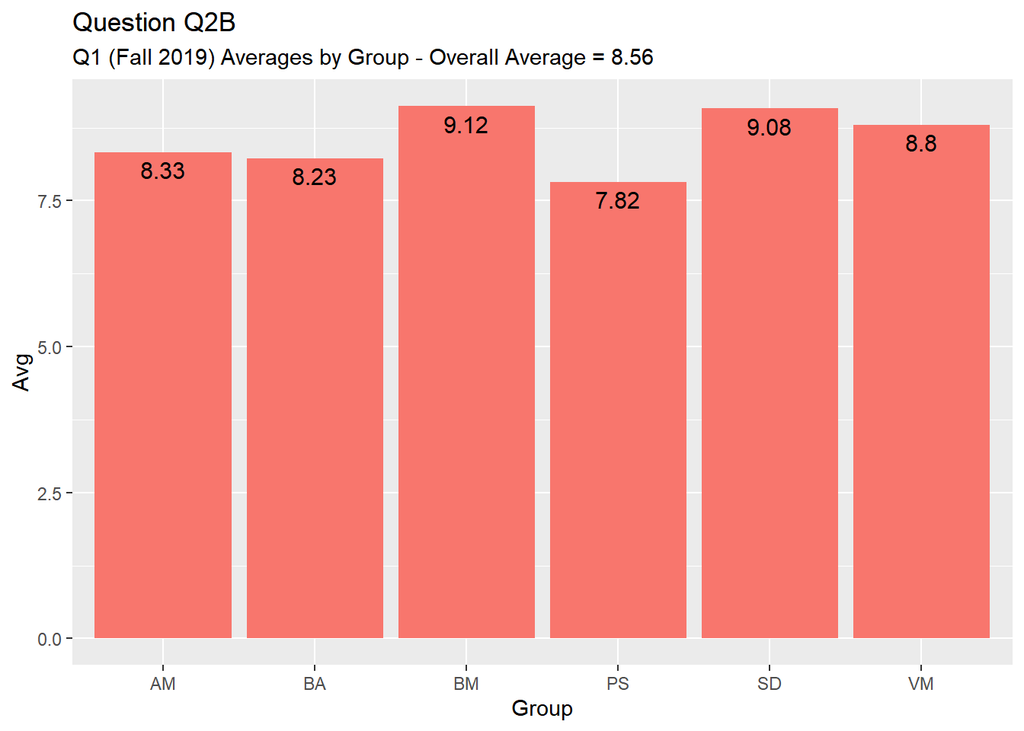

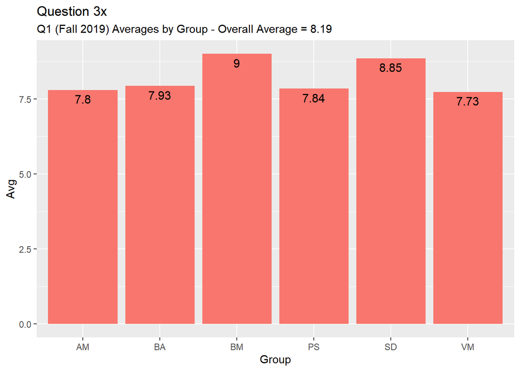

[End of Report]